# Analysis of effect of advertising on the sales

## *I. Simple linear regression:*

In simple linear regression, there is only one independent variable x and the relationship between the dependent variable y and x is modeled as straight line:  
𝑦= $\alpha$ + ${\beta x}$

$\beta$ is the slope of the line and $\alpha$ is the intercept. Together, $\alpha$ and $\beta$ are known as the model coefficients or parameters.Once we have used training data to produce estimates $\hat{\alpha}$ and $\hat{\beta}$ for the model coefficients, we can predict future values of y by using the following equation:  
$\hat{y}$ = $\hat{\alpha}$ + $\hat{\beta} x$

Where $\hat{y}$ is the predicted value (it could differ from the actual value y)

Let $\hat{y_{i}}$ = $\hat{\alpha}$ + $\hat{\beta} x_{i}$ be the prediction for y based on the ith value of x.  
Then $e_{i}$ = $y_{i}$ − $\hat{y_{i}}$ represents the ith residual — this is the difference between the ith observed value and the ith value that is predicted by our linear model. In a sense, it measures the error of prediction for the ith value.

We define the residual sum of squares (RSS) as:  
RSS = $\sum {(y_{i} − \hat{y_{i}})^2}$ = $\sum e_{i}^2$

The Ordinary Least Squares (OLS) method determines $\hat{\alpha}$ and $\hat{\beta}$ so that to minimize RSS. It is mathematically proved that RSS is minimized for the following values of $\hat{\alpha}$ and $\hat{\beta}$: $\hat{\beta} = \sum (x_{i} - \overline{x})(y_{i} - \overline{y})/\sum (x_{i} - \overline{x})^2$

$\hat{\alpha} = \overline{y} − \hat{\beta} \overline{x}$

## *II. Applying Simple linear regression to predict sales:*

### **Data Exploration:**

**1. Reading Advertising data from the file into a data frame:**

```r
advertising = read.csv("Advertising.csv")
```

2.  
i. Structure of the dataset:

```r
  str(advertising)
```

```
'data.frame':   200 obs. of  4 variables:
 $ TV       : num  230.1 44.5 17.2 151.5 180.8 ...
 $ radio    : num  37.8 39.3 45.9 41.3 10.8 48.9 32.8 19.6 2.1 2.6 ...
 $ newspaper: num  69.2 45.1 69.3 58.5 58.4 75 23.5 11.6 1 21.2 ...
 $ sales    : num  22.1 10.4 9.3 18.5 12.9 7.2 11.8 13.2 4.8 10.6 ...
```

The dataset contains 200 observations and four variables: the money that is spent on TV, newspaper, or radio ads and the sales in thousand dollars. **We want to study the relationship between sales and TV ads.**

3.  
i. Scatterplot to analyse correlation between TV ads and sales:

```r
attach(advertising)
```

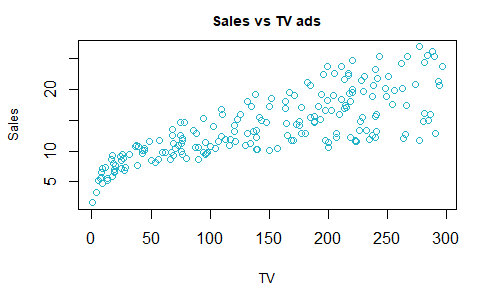

```r
plot(sales ~ TV, col = "#22B3C8", ylab = "Sales", xlab = "TV", main = "Sales vs TV ads", cex.lab = 0.8, cex.main = 0.9)
```

From the scatterplot we can say there exists a positive correlation between sales and TV ads.  
ii. Analyse correlation between TV ads and sales using cor function:**

```r
cor(TV, sales)
```

```
[1] 0.7822244
```

cor function shows there is a strong enough positive correlation between TV and sales.

**4. Using lm() function to fit a linear regression model to the data:**

```r
advertising_lm = lm(sales ~ TV, data = advertising)
coefficients(advertising_lm)
```

```
(Intercept)          TV
 7.03259355  0.04753664
```

In other words $\hat{\alpha}$ = 7.03259355 and $\hat{\beta}$ = 0.04753664

**5. Using coefficients from linear regression model to draw a line through the scatterplot:**

```r
plot(sales ~ TV, col = "#22B3C8", ylab = "Sales", xlab = "TV", main = "Sales vs TV ads", cex.lab = 0.8, cex.main = 0.9)
abline( 7.03259355,0.04753664,col="deeppink4" )
```

[output not shown]